# EasyVisa Project

## Context:

Business communities in the United States are facing high demand for human resources, but one of the constant challenges is identifying and attracting the right talent, which is perhaps the most important element in remaining competitive. Companies in the United States look for hard-working, talented, and qualified individuals both locally as well as abroad.

The Immigration and Nationality Act (INA) of the US permits foreign workers to come to the United States to work on either a temporary or permanent basis. The act also protects US workers against adverse impacts on their wages or working conditions by ensuring US employers' compliance with statutory requirements when they hire foreign workers to fill workforce shortages. The immigration programs are administered by the Office of Foreign Labor Certification (OFLC).

OFLC processes job certification applications for employers seeking to bring foreign workers into the United States and grants certifications in those cases where employers can demonstrate that there are not sufficient US workers available to perform the work at wages that meet or exceed the wage paid for the occupation in the area of intended employment.

## Objective:

In FY 2016, the OFLC processed 775,979 employer applications for 1,699,957 positions for temporary and permanent labor certifications. This was a nine percent increase in the overall number of processed applications from the previous year. The process of reviewing every case is becoming a tedious task as the number of applicants is increasing every year.

The increasing number of applicants every year calls for a Machine Learning based solution that can help in shortlisting the candidates having higher chances of VISA approval. OFLC has hired your firm EasyVisa for data-driven solutions. You as a data scientist have to analyze the data provided and, with the help of a classification model:

- Facilitate the process of visa approvals.
- Recommend a suitable profile for the applicants for whom the visa should be certified or denied based on the drivers that significantly influence the case status.

## Data Description

The data contains the different attributes of the employee and the employer. The detailed data dictionary is given below.

- case_id: ID of each visa application
- continent: Information of continent the employee
- education_of_employee: Information of education of the employee
- has_job_experience: Does the employee has any job experience? Y= Yes; N = No
- requires_job_training: Does the employee require any job training? Y = Yes; N = No
- no_of_employees: Number of employees in the employer's company
- yr_of_estab: Year in which the employer's company was established
- region_of_employment: Information of foreign worker's intended region of employment in the US.
- prevailing_wage: Average wage paid to similarly employed workers in a specific occupation in the area of intended employment. The purpose of the prevailing wage is to ensure that the foreign worker is not underpaid compared to other workers offering the same or similar service in the same area of employment.
- unit_of_wage: Unit of prevailing wage. Values include Hourly, Weekly, Monthly, and Yearly.
- full_time_position: Is the position of work full-time? Y = Full Time Position; N = Part Time Position
- case_status: Flag indicating if the Visa was certified or denied

## Importing necessary libraries and data

```python
# Libraries to help with reading and manipulating data
import numpy as np
import pandas as pd

# libaries to help with data visualization
import matplotlib.pyplot as plt
import seaborn as sns

# Library to split data
from sklearn.model_selection import train_test_split

from sklearn import tree
from sklearn.tree import DecisionTreeClassifier
from sklearn.model_selection import GridSearchCV
# Libraries different ensemble classifiers
from sklearn.ensemble import (
    BaggingClassifier,
    RandomForestClassifier,
    AdaBoostClassifier,
    GradientBoostingClassifier,
    StackingClassifier,
)

from sklearn import metrics
from sklearn.metrics import (
    confusion_matrix,
    accuracy_score,
    precision_score,
    recall_score,
    f1_score,
)
import scipy.stats as stats

import warnings
warnings.filterwarnings('ignore')

# Removes the limit for the number of displayed columns
pd.set_option("display.max_columns", None)
# Sets the limit for the number of displayed rows
pd.set_option("display.max_rows", 100)

from xgboost import XGBClassifier

from google.colab import drive
drive.mount('/content/drive')
```

```python
#read dataset
visa = pd.read_csv('/content/drive/MyDrive/DSBA Certificate/learning files (csv)/EasyVisa.csv')
```

```python
#copy safekeeping
data = visa.copy()
```

## Data Overview

- Observations
- Sanity checks

```python
#sneak peek of dataset
data.head()
```

|  | case_id | continent | education_of_employee | has_job_experience | requires_job_training | no_of_employees | yr_of_estab | region_of_employment | prevailing_wage | unit_of_wage | full_time_position | case_status |
| --- | --- | --- | --- | --- | --- | --- | --- | --- | --- | --- | --- | --- |
| 0 | EZYV01 | Asia | High School | N | N | 14513 | 2007 | West | 592.2029 | Hour | Y | Denied |
| 1 | EZYV02 | Asia | Master's | Y | N | 2412 | 2002 | Northeast | 83425.6500 | Year | Y | Certified |
| 2 | EZYV03 | Asia | Bachelor's | N | Y | 44444 | 2008 | West | 122996.8600 | Year | Y | Denied |
| 3 | EZYV04 | Asia | Bachelor's | N | N | 98 | 1897 | West | 83434.0300 | Year | Y | Denied |
| 4 | EZYV05 | Africa | Master's | Y | N | 1082 | 2005 | South | 149907.3900 | Year | Y | Certified |

```python
#shape check
data.shape
```

```
(25480, 12)
```

There are 25,480 rows and 12 columns in the dataset.

```python
data.info()
```

```
<class 'pandas.core.frame.DataFrame'>
RangeIndex: 25480 entries, 0 to 25479
Data columns (total 12 columns):
 #   Column                 Non-Null Count  Dtype
---  ------                 --------------  -----
 0   case_id                25480 non-null  object
 1   continent              25480 non-null  object
 2   education_of_employee  25480 non-null  object
 3   has_job_experience     25480 non-null  object
 4   requires_job_training  25480 non-null  object
 5   no_of_employees        25480 non-null  int64
 6   yr_of_estab            25480 non-null  int64
 7   region_of_employment   25480 non-null  object
 8   prevailing_wage        25480 non-null  float64
 9   unit_of_wage           25480 non-null  object
 10  full_time_position     25480 non-null  object
 11  case_status            25480 non-null  object
dtypes: float64(1), int64(2), object(9)
memory usage: 2.3+ MB
```

```python
#check missing
data.isnull().sum()
```

```
case_id                  0
continent                0
education_of_employee    0
has_job_experience       0
requires_job_training    0
no_of_employees          0
yr_of_estab              0
region_of_employment     0
prevailing_wage          0
unit_of_wage             0
full_time_position       0
case_status              0
dtype: int64
```

There are no missing entries in the data!

```python
data.nunique()
```

```
case_id                  25480
continent                    6
education_of_employee        4
has_job_experience           2
requires_job_training        2
no_of_employees           7105
yr_of_estab                199
region_of_employment         5
prevailing_wage          25454
unit_of_wage                 4
full_time_position           2
case_status                  2
dtype: int64
```

We see that case_id has a unique entry for every row. This information can be removed as it will not serve us in identifying a pattern.

```python
#remove case_id because all unique values
data.drop('case_id', axis=1, inplace=True)
```

```python
#fix data types
#object to category
cols = data.select_dtypes(['object'])
cols.columns
```

```
Index(['continent', 'education_of_employee', 'has_job_experience',
       'requires_job_training', 'region_of_employment', 'unit_of_wage',
       'full_time_position', 'case_status'],
      dtype='object')
```

```python
for i in cols.columns:
  data[i] = data[i].astype('category')
```

```python
#check data types
data.info()
```

```
<class 'pandas.core.frame.DataFrame'>
RangeIndex: 25480 entries, 0 to 25479
Data columns (total 11 columns):
 #   Column                 Non-Null Count  Dtype
---  ------                 --------------  -----
 0   continent              25480 non-null  category
 1   education_of_employee  25480 non-null  category
 2   has_job_experience     25480 non-null  category
 3   requires_job_training  25480 non-null  category
 4   no_of_employees        25480 non-null  int64
 5   yr_of_estab            25480 non-null  int64
 6   region_of_employment   25480 non-null  category
 7   prevailing_wage        25480 non-null  float64
 8   unit_of_wage           25480 non-null  category
 9   full_time_position     25480 non-null  category
 10  case_status            25480 non-null  category
dtypes: category(8), float64(1), int64(2)
memory usage: 797.7 KB
```

```python
#observe changes in first few rows of dataset
data.head()
```

|  | continent | education_of_employee | has_job_experience | requires_job_training | no_of_employees | yr_of_estab | region_of_employment | prevailing_wage | unit_of_wage | full_time_position | case_status |
| --- | --- | --- | --- | --- | --- | --- | --- | --- | --- | --- | --- |
| 0 | Asia | High School | N | N | 14513 | 2007 | West | 592.2029 | Hour | Y | Denied |
| 1 | Asia | Master's | Y | N | 2412 | 2002 | Northeast | 83425.6500 | Year | Y | Certified |
| 2 | Asia | Bachelor's | N | Y | 44444 | 2008 | West | 122996.8600 | Year | Y | Denied |
| 3 | Asia | Bachelor's | N | N | 98 | 1897 | West | 83434.0300 | Year | Y | Denied |
| 4 | Africa | Master's | Y | N | 1082 | 2005 | South | 149907.3900 | Year | Y | Certified |

```python
#statistical summary
data.describe().T
```

|  | count | mean | std | min | 25% | 50% | 75% | max |
| --- | --- | --- | --- | --- | --- | --- | --- | --- |
| no_of_employees | 25480.0 | 5667.043210 | 22877.928848 | -26.0000 | 1022.00 | 2109.00 | 3504.0000 | 602069.00 |
| yr_of_estab | 25480.0 | 1979.409929 | 42.366929 | 1800.0000 | 1976.00 | 1997.00 | 2005.0000 | 2016.00 |
| prevailing_wage | 25480.0 | 74455.814592 | 52815.942327 | 2.1367 | 34015.48 | 70308.21 | 107735.5125 | 319210.27 |

- we observe a strange minimum value for no_of_employees. There should not be negatives representing this value. We will fix this by applying absolute values.
- The businesses have a range of year established from 1800 to 2016. There are some older companies, but 75% of the data includes companies from 1976 on.
- The prevailing wage column has a high variety of values, but this is understandable as our data also includes unit_of_wage; the minimum of 2.1367 is likely an hourly rate, whereas the maximum of 319210 is likely an annual rate.

```python
#summary including categories
data.describe(include=['category']).T
```

|  | count | unique | top | freq |
| --- | --- | --- | --- | --- |
| continent | 25480 | 6 | Asia | 16861 |
| education_of_employee | 25480 | 4 | Bachelor's | 10234 |
| has_job_experience | 25480 | 2 | Y | 14802 |
| requires_job_training | 25480 | 2 | N | 22525 |
| region_of_employment | 25480 | 5 | Northeast | 7195 |
| unit_of_wage | 25480 | 4 | Year | 22962 |
| full_time_position | 25480 | 2 | Y | 22773 |
| case_status | 25480 | 2 | Certified | 17018 |

- The data includes applications from 6 continents. The most popular being Asia.
- The most common level of education is a Bachelor's Degree.
- The majority of the applicants have job experience and do not require job training. It will be worth investigating if this demographic has a higher rate of certification.
- Most of the data pertains to Yearly units of wage with a full time position.
- We observe that applicants' case_status are more often Certified than Denied.

```python
#check unique values of categorical columns
cat_cols = data.select_dtypes(['category'])
for i in cat_cols.columns:
  print('Unique values in', i, 'are:')
  print(data[i].value_counts())
  print('*'*30)
```

```
Unique values in continent are:
continent
Asia             16861
Europe            3732
North America     3292
South America      852
Africa             551
Oceania            192
Name: count, dtype: int64
Unique values in education_of_employee are:
education_of_employee
Bachelor's     10234
Master's        9634
High School     3420
Doctorate       2192
Name: count, dtype: int64
Unique values in has_job_experience are:
has_job_experience
Y    14802
N    10678
Name: count, dtype: int64
Unique values in requires_job_training are:
requires_job_training
N    22525
Y     2955
Name: count, dtype: int64
Unique values in region_of_employment are:
region_of_employment
Northeast    7195
South        7017
West         6586
Midwest      4307
Island        375
Name: count, dtype: int64
Unique values in unit_of_wage are:
unit_of_wage
Year     22962
Hour      2157
Week       272
Month       89
Name: count, dtype: int64
Unique values in full_time_position are:
full_time_position
Y    22773
N     2707
Name: count, dtype: int64
Unique values in case_status are:
case_status
Certified    17018
Denied        8462
Name: count, dtype: int64
```

```python
#fix negatives in employee counts
data.loc[data['no_of_employees']<0].shape
```

```
(33, 11)
```

```python
print('there are 33 negative values in the column. We will fix them.')
data['no_of_employees'] = data['no_of_employees'].abs()
data.loc[data['no_of_employees']<0].shape
```

```
there are 33 negative values in the column. We will fix them.
```

```
(0, 11)
```

## Exploratory Data Analysis (EDA)

- EDA is an important part of any project involving data.
- It is important to investigate and understand the data better before building a model with it.
- A few questions have been mentioned below which will help you approach the analysis in the right manner and generate insights from the data.
- A thorough analysis of the data, in addition to the questions mentioned below, should be done.

```python
#save data
df = data.copy()
```

```python
#import shared visualization codes
def histogram_boxplot(data, feature, figsize=(15, 10), kde=False, bins=None):
    """
    Boxplot and histogram combined

    data: dataframe
    feature: dataframe column
    figsize: size of figure (default (15,10))
    kde: whether to show the density curve (default False)
    bins: number of bins for histogram (default None)
    """
    f2, (ax_box2, ax_hist2) = plt.subplots(
        nrows=2,  # Number of rows of the subplot grid= 2
        sharex=True,  # x-axis will be shared among all subplots
        gridspec_kw={"height_ratios": (0.25, 0.75)},
        figsize=figsize,
    )  # creating the 2 subplots
    sns.boxplot(
        data=data, x=feature, ax=ax_box2, showmeans=True, color="violet"
    )  # boxplot will be created and a triangle will indicate the mean value of the column
    sns.histplot(
        data=data, x=feature, kde=kde, ax=ax_hist2, bins=bins
    ) if bins else sns.histplot(
        data=data, x=feature, kde=kde, ax=ax_hist2
    )  # For histogram
    ax_hist2.axvline(
        data[feature].mean(), color="green", linestyle="--"
    )  # Add mean to the histogram
    ax_hist2.axvline(
        data[feature].median(), color="black", linestyle="-"
    )  # Add median to the histogram

# function to create labeled barplots


def labeled_barplot(data, feature, perc=True, n=None):
    """
    Barplot with percentage at the top

    data: dataframe
    feature: dataframe column
    perc: whether to display percentages instead of count (default is False)
    n: displays the top n category levels (default is None, i.e., display all levels)
    """

    total = len(data[feature])  # length of the column
    count = data[feature].nunique()
    if n is None:
        plt.figure(figsize=(count + 2, 6))
    else:
        plt.figure(figsize=(n + 2, 6))

    plt.xticks(rotation=90, fontsize=15)
    ax = sns.countplot(
        data=data,
        x=feature,
        palette="Paired",
        order=data[feature].value_counts().index[:n],
    )

    for p in ax.patches:
        if perc == True:
            label = "{:.1f}%".format(
                100 * p.get_height() / total
            )  # percentage of each class of the category
        else:
            label = p.get_height()  # count of each level of the category

        x = p.get_x() + p.get_width() / 2  # width of the plot
        y = p.get_height()  # height of the plot

        ax.annotate(
            label,
            (x, y),
            ha="center",
            va="center",
            size=12,
            xytext=(0, 5),
            textcoords="offset points",
        )  # annotate the percentage

    plt.show()  # show the plot


# function to plot stacked bar chart

def stacked_barplot(data, predictor, target):
    """
    Print the category counts and plot a stacked bar chart

    data: dataframe
    predictor: independent variable
    target: target variable
    """
    count = data[predictor].nunique()
    sorter = data[target].value_counts().index[-1]
    tab1 = pd.crosstab(data[predictor], data[target], margins=True).sort_values(
        by=sorter, ascending=False
    )
    print(tab1)
    print("-" * 120)
    tab = pd.crosstab(data[predictor], data[target], normalize="index").sort_values(
        by=sorter, ascending=False
    )
    tab.plot(kind="bar", stacked=True, figsize=(count + 1, 5))
    plt.legend(
        loc="lower left",
        frameon=False,
    )
    plt.legend(loc="upper left", bbox_to_anchor=(1, 1))
    plt.show()

### function to plot distributions wrt target


def distribution_plot_wrt_target(data, predictor, target):

    fig, axs = plt.subplots(2, 2, figsize=(12, 10))

    target_uniq = data[target].unique()

    axs[0, 0].set_title("Distribution of target for target=" + str(target_uniq[0]))
    sns.histplot(
        data=data[data[target] == target_uniq[0]],
        x=predictor,
        kde=True,
        ax=axs[0, 0],
        color="teal",
        stat="density",
    )

    axs[0, 1].set_title("Distribution of target for target=" + str(target_uniq[1]))
    sns.histplot(
        data=data[data[target] == target_uniq[1]],
        x=predictor,
        kde=True,
        ax=axs[0, 1],
        color="orange",
        stat="density",
    )

    axs[1, 0].set_title("Boxplot w.r.t target")
    sns.boxplot(data=data, x=target, y=predictor, ax=axs[1, 0], palette="gist_rainbow")

    axs[1, 1].set_title("Boxplot (without outliers) w.r.t target")
    sns.boxplot(
        data=data,
        x=target,
        y=predictor,
        ax=axs[1, 1],
        showfliers=False,
        palette="gist_rainbow",
    )

    plt.tight_layout()
    plt.show()
```

**Leading Questions**:

1. Those with higher education may want to travel abroad for a well-paid job. Does education play a role in Visa certification?
2. How does the visa status vary across different continents?
3. Experienced professionals might look abroad for opportunities to improve their lifestyles and career development. Does work experience influence visa status?
4. In the United States, employees are paid at different intervals. Which pay unit is most likely to be certified for a visa?
5. The US government has established a prevailing wage to protect local talent and foreign workers. How does the visa status change with the prevailing wage?

### Univariate Analysis

See below for information regarding patterns of each column in the dataset.

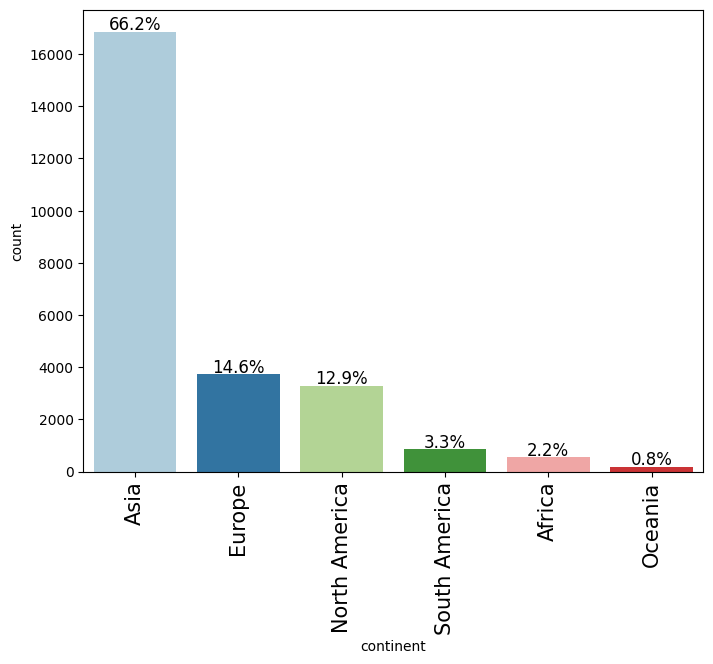

```python
#continent barplot
labeled_barplot(df, 'continent')
```

66.2% of applicants come from Asia. Less than 10% of applicants come from South America, Africa, or Oceania. Perhaps there are less applicants from these location because they have a pattern of being denied? We will investigate this relationship below in our Bivariate Analysis.

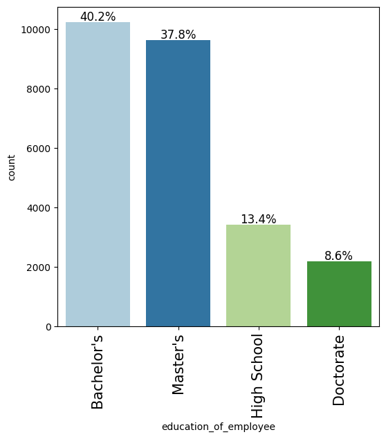

```python
#education level barplot
labeled_barplot(df, 'education_of_employee')
```

As seen in the overview, the most common education level is a Bachelor's degree. A close second is Master's Degree. ~22% of applicants have the highest and lowest education levels (High School and Doctorate)

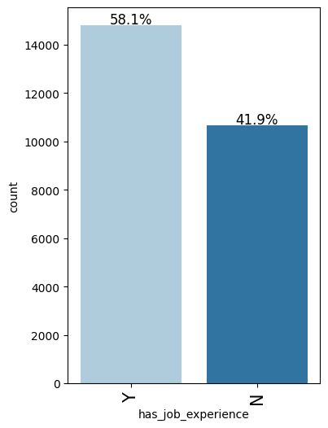

```python
#job experience barplot
labeled_barplot(df, 'has_job_experience')
```

More than half of the applicants have prior job experience. We will investigate if experience serves a role in case_status in the Bivariate Analysis section.

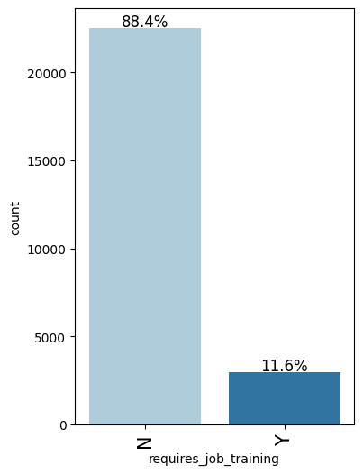

```python
#job training barplot
labeled_barplot(df, 'requires_job_training')
```

A very high percentage of applicants do not require job training. It is interesting to note that this value of 88.4% is higher than the value seen of having job experience (58.1%). This shows us that even if an applicant does not have experience, they still might not require training.

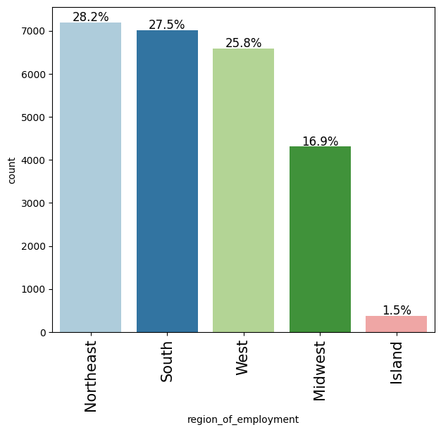

```python
#region barplot
labeled_barplot(df, 'region_of_employment')
```

Few applicants seek employment in the Midwest or Island regions. This most popular regions to work are the Northeast and South (~55.7% of data).

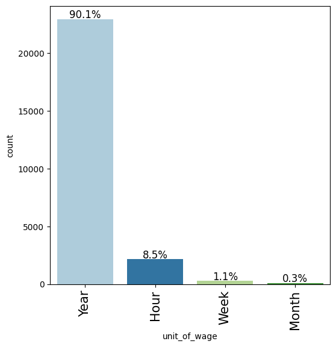

```python
#wage unit barplot
labeled_barplot(df, 'unit_of_wage')
```

Less than 2% of the data relates to weekly or monthly units of wage.

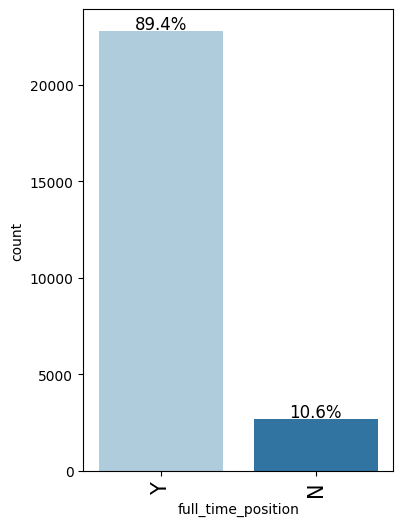

```python
#full time or not barplot
labeled_barplot(df, 'full_time_position')
```

A large majority of the data is in reference to full time work. Non-full time could be related to seasonal jobs.

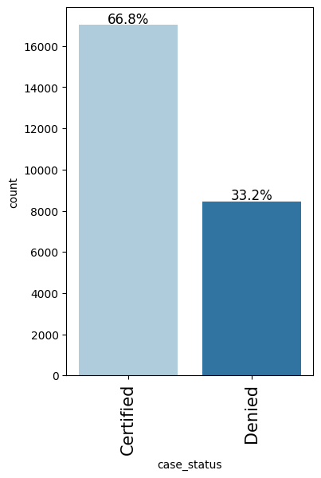

```python
#case status barplot (dependent variable)
labeled_barplot(df, 'case_status')
```

66.8% of the applicants receive certification and 33.2% are denied. This split calls for us to stratify the data when we build our models.

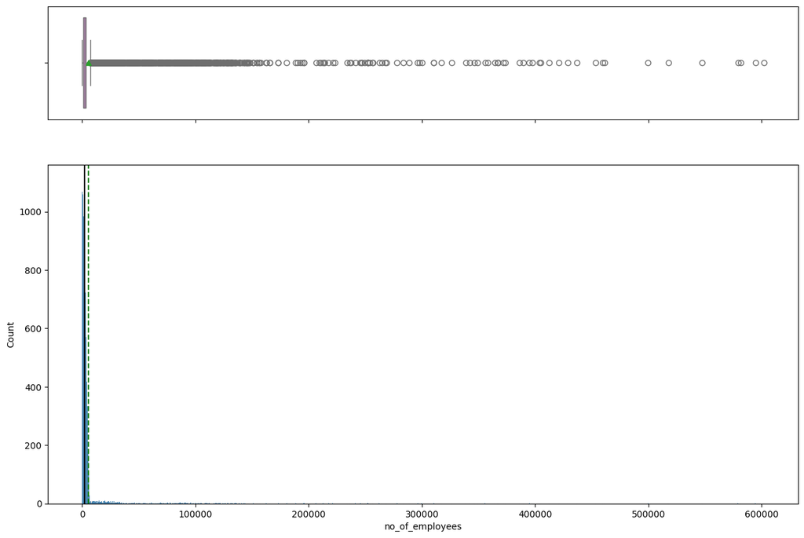

```python
#number employees visualization
histogram_boxplot(df, 'no_of_employees')
```

```python
df.no_of_employees.median()
```

```
2109.0
```

The data is strongly skewed to the right. The median value shows us that companies can have an expected 2,109 employees.

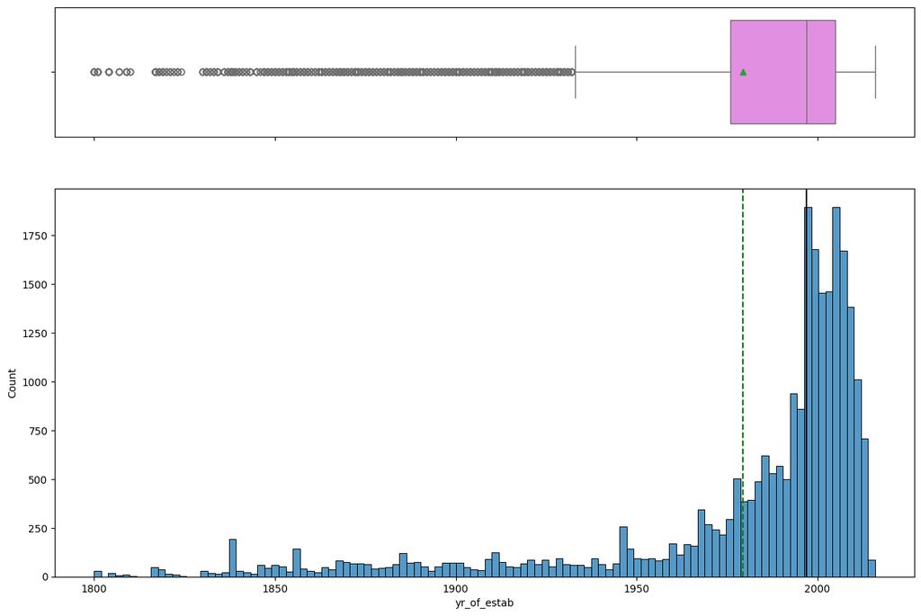

```python
#year established visualization
histogram_boxplot(df, 'yr_of_estab')
```

The data is skewed left as there are companies that have been around since the 1800's. There are more applicants for newer comapnies from 2000-2016.

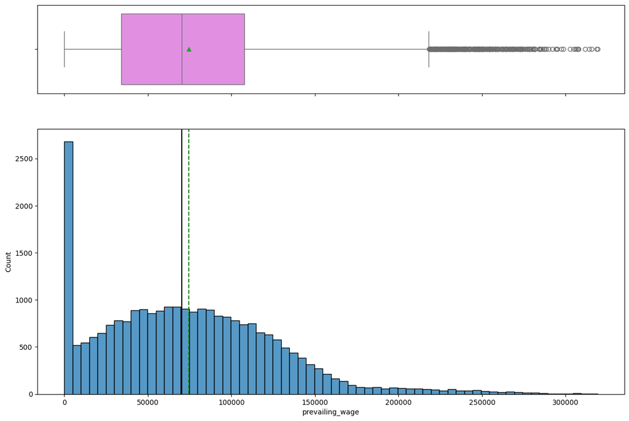

```python
#prevailing wage visualization
histogram_boxplot(df, 'prevailing_wage')
```

There is a slight right-skew to the data, but the high count of wages less than 1000 also pulls to the left. We can further investigate where these values are in our data.

```python
#understand high count of low wages seen above
df.loc[df['prevailing_wage']<100]
```

|  | continent | education_of_employee | has_job_experience | requires_job_training | no_of_employees | yr_of_estab | region_of_employment | prevailing_wage | unit_of_wage | full_time_position | case_status |
| --- | --- | --- | --- | --- | --- | --- | --- | --- | --- | --- | --- |
| 338 | Asia | Bachelor's | Y | N | 2114 | 2012 | Northeast | 15.7716 | Hour | Y | Certified |
| 634 | Asia | Master's | N | N | 834 | 1977 | Northeast | 3.3188 | Hour | Y | Denied |
| 839 | Asia | High School | Y | N | 4537 | 1999 | West | 61.1329 | Hour | Y | Denied |
| 876 | South America | Bachelor's | Y | N | 731 | 2004 | Northeast | 82.0029 | Hour | Y | Denied |
| 995 | Asia | Master's | N | N | 302 | 2000 | South | 47.4872 | Hour | Y | Certified |
| ... | ... | ... | ... | ... | ... | ... | ... | ... | ... | ... | ... |
| 25023 | Asia | Bachelor's | N | Y | 3200 | 1994 | South | 94.1546 | Hour | Y | Denied |
| 25258 | Asia | Bachelor's | Y | N | 3659 | 1997 | South | 79.1099 | Hour | Y | Denied |
| 25308 | North America | Master's | N | N | 82953 | 1977 | Northeast | 42.7705 | Hour | Y | Denied |
| 25329 | Africa | Bachelor's | N | N | 2172 | 1993 | Northeast | 32.9286 | Hour | Y | Denied |
| 25461 | Asia | Master's | Y | N | 2861 | 2004 | West | 54.9196 | Hour | Y | Denied |

176 rows × 11 columns

There are 176 instances of wages less than 100 for prevailing wage.

```python
#understand high count of low wages seen above
df.loc[(df['prevailing_wage']<100) & (df['unit_of_wage']=='Hour')].count()
```

```
continent                176
education_of_employee    176
has_job_experience       176
requires_job_training    176
no_of_employees          176
yr_of_estab              176
region_of_employment     176
prevailing_wage          176
unit_of_wage             176
full_time_position       176
case_status              176
dtype: int64
```

Of the 176 instances of low wages, all of the entries are of Hourly type. This makes sense that a lower prevailing wage would be displayed for this category.

### Bivariate Analysis

Please see below for information regarding relationships between columns of the dataset

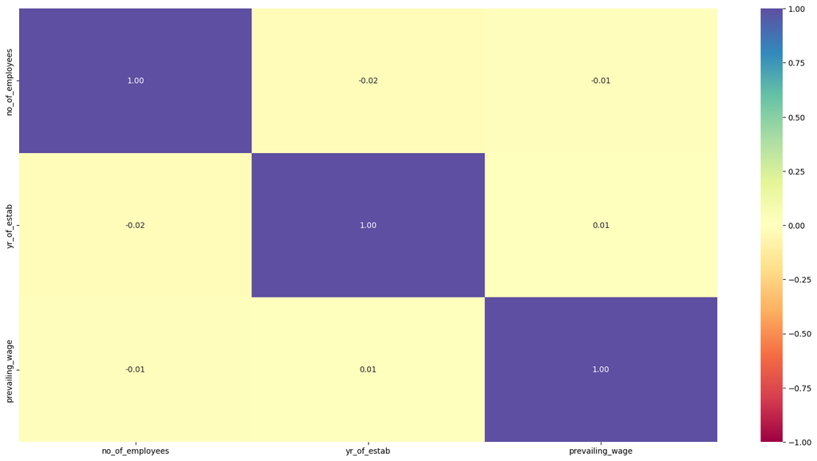

```python
cols_list = df.select_dtypes(include=np.number).columns.tolist()
plt.figure(figsize=(20,10))
sns.heatmap(df[cols_list].corr(),annot=True,vmin=-1,vmax=1,fmt='.2f',cmap="Spectral")
plt.show()
```

There is not significant correlation amongst the numeric columns.

```
case_status            Certified  Denied    All
education_of_employee
All                        17018    8462  25480
Bachelor's                  6367    3867  10234
High School                 1164    2256   3420
Master's                    7575    2059   9634
Doctorate                   1912     280   2192
------------------------------------------------------------------------------------------------------------------------
```

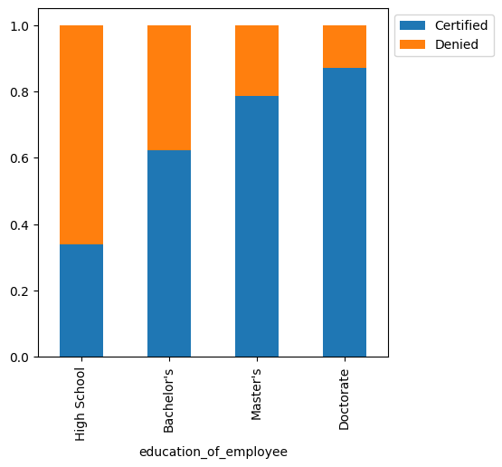

```python
#question 1: education and visa
stacked_barplot(df, 'education_of_employee', 'case_status')
```

**Question 1:** There is a trend that, as education level increases, an applicant is more likely to be certified. It is more likely than not for an applicant with only a high school education to be denied, whereas it is more likely for an applicant with a doctorate to receive certification.

```
case_status    Certified  Denied    All
continent
All                17018    8462  25480
Asia               11012    5849  16861
North America       2037    1255   3292
Europe              2957     775   3732
South America        493     359    852
Africa               397     154    551
Oceania              122      70    192
------------------------------------------------------------------------------------------------------------------------
```

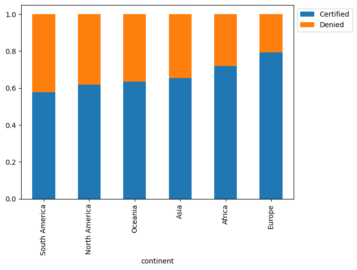

```python
#question 2: visa status and continents
stacked_barplot(df, 'continent', 'case_status')
```

**Question 2:** Although we observed that most applicants are from Asia, this continent does not receive the most certifications. An applicant from Europe is most likely to receive certification. It is worth mentioning that there is not a continent with *significantly* less certifications than the others; it is good to know there does not seem to be a bias towards a particular continent.

```
case_status         Certified  Denied    All
has_job_experience
All                     17018    8462  25480
N                        5994    4684  10678
Y                       11024    3778  14802
------------------------------------------------------------------------------------------------------------------------
```

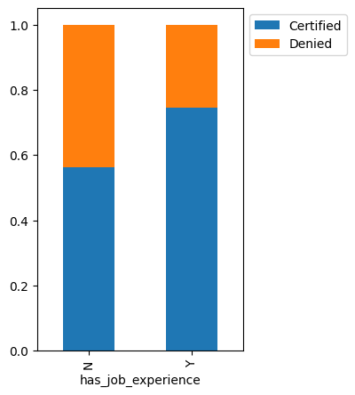

```python
#question 3: work experience and visa status
stacked_barplot(df, 'has_job_experience', 'case_status')
```

**Question 3:** It seems that having work experience has a higher rate of certification in comparison to those without.

```
case_status   Certified  Denied    All
unit_of_wage
All               17018    8462  25480
Year              16047    6915  22962
Hour                747    1410   2157
Week                169     103    272
Month                55      34     89
------------------------------------------------------------------------------------------------------------------------
```

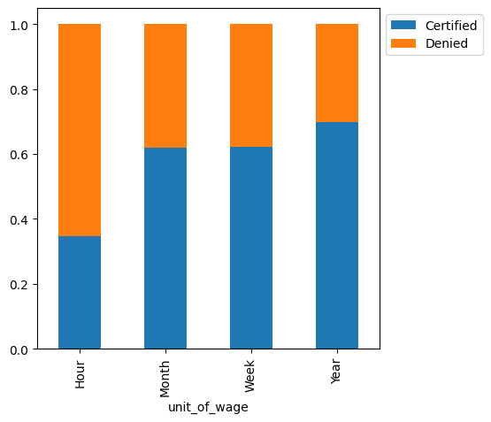

```python
#question 4: unit of wage and visa status
stacked_barplot(df, 'unit_of_wage', 'case_status')
```

**Question 4:** Approx. 30% of applicants looking for an hourly job are certified, whereas the certifications of those looking for a Monthly, Weekly, or Yearly unit of wage are approx. 60% or greater.

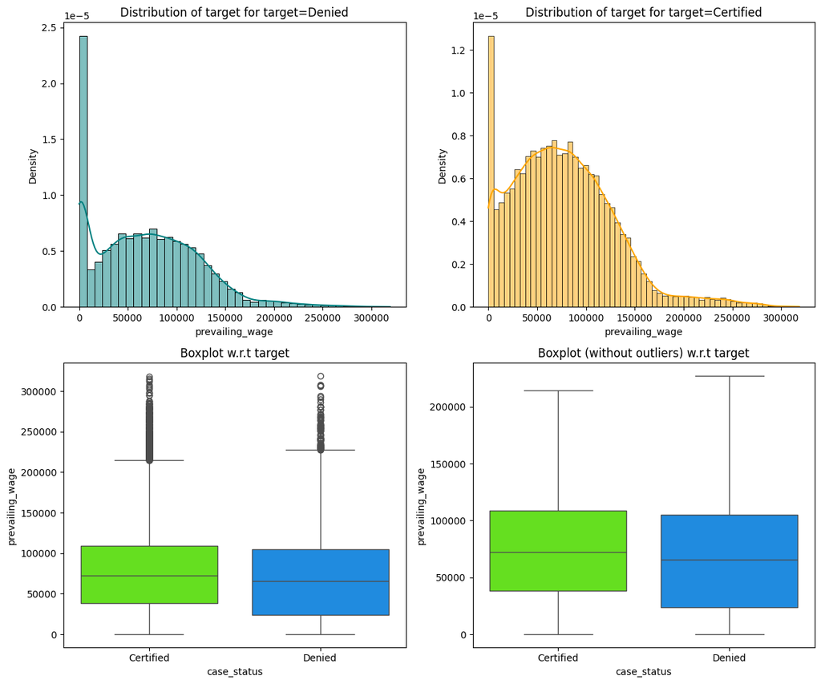

```python
#question 5: visa status and prevailing wage
distribution_plot_wrt_target(df, 'prevailing_wage', 'case_status')
```

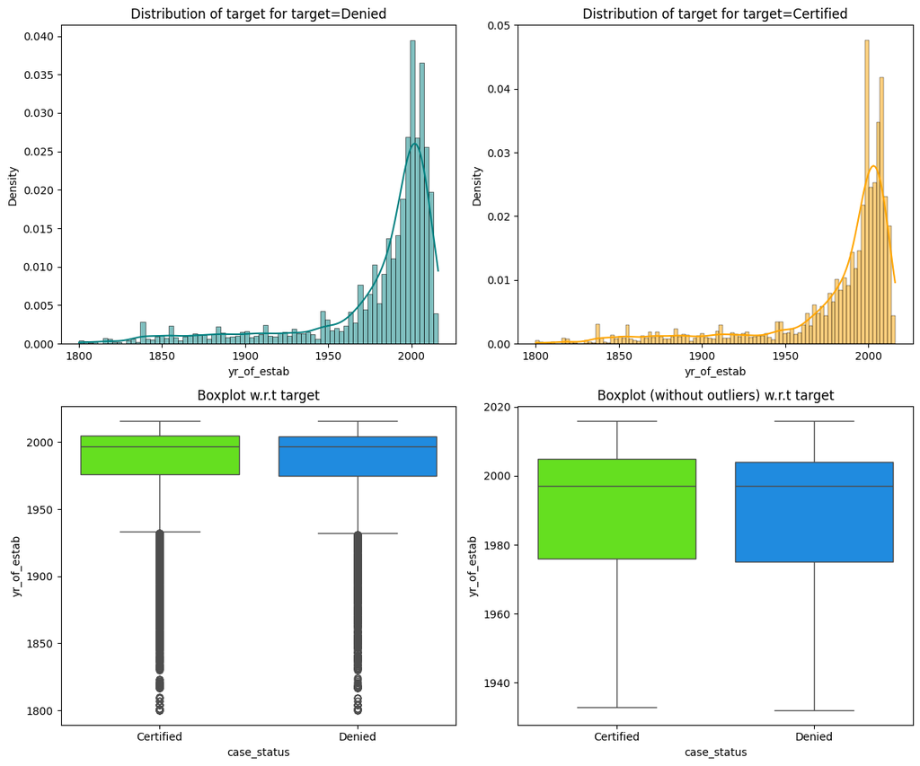

```python
#year established and visa status
distribution_plot_wrt_target(df, 'yr_of_estab', 'case_status')
```

The year a business was established does not display a pattern for having certified vs. denied applications as their histograms and boxplots are quite similar.

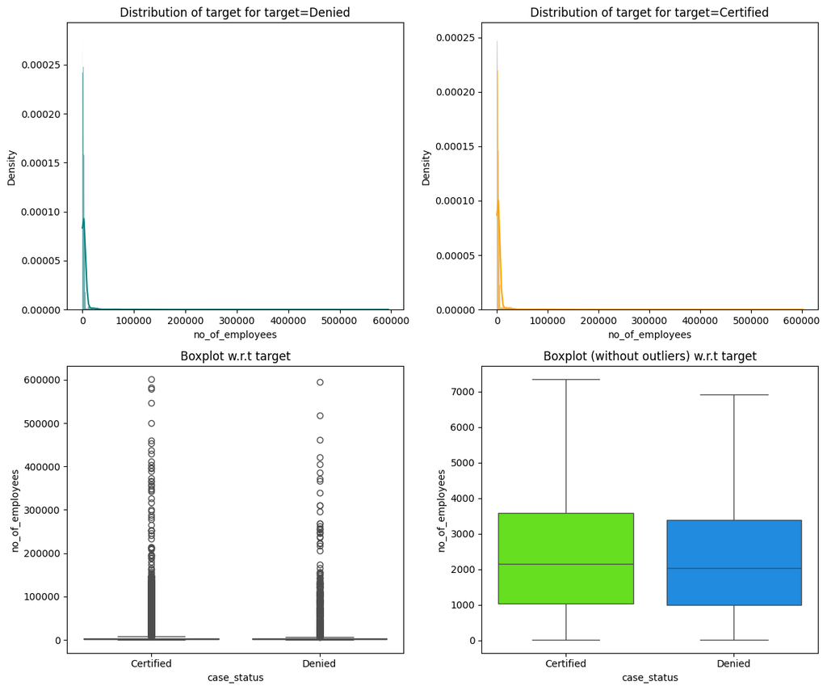

```python
#number employees and visa status
distribution_plot_wrt_target(df, 'no_of_employees', 'case_status')
```

The number of employees in a company does not display a significant pattern for having certified vs. denied applications as their histograms and boxplots are quite similar. There is a slightly larger median for certified apllications compared to denied, but not a large enough difference to make a statement.

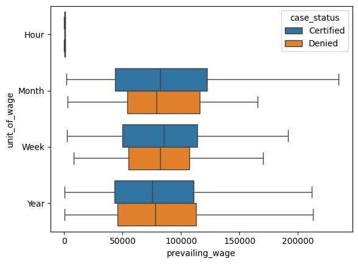

```python
#relationship between unit of wage and prevailing wage
sns.boxplot(data=df, x='prevailing_wage', y='unit_of_wage', hue='case_status', showfliers=False)
plt.show()
```

The spreads of the unit_of_wage boxplots are comparable within their cerified/denied splits. Higher prevailing_wage for Week and Month categories show more certifications.

```
has_job_experience         N      Y    All
education_of_employee
All                    10678  14802  25480
Bachelor's              4348   5886  10234
Master's                3993   5641   9634
High School             1396   2024   3420
Doctorate                941   1251   2192
------------------------------------------------------------------------------------------------------------------------
```

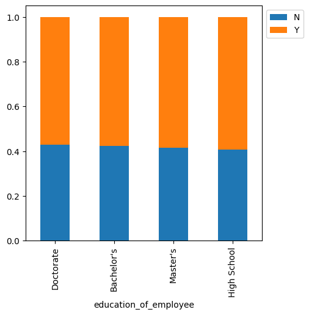

```python
#relationship between education and experience
stacked_barplot(df, 'education_of_employee', 'has_job_experience')
```

The job experience of an applicant does not vary much amongst the education levels. *Approximately* 40% of each education level does not have prior experience, and 60% do have prior experience.

```
requires_job_training      N     Y    All
has_job_experience
All                    22525  2955  25480
N                       8988  1690  10678
Y                      13537  1265  14802
------------------------------------------------------------------------------------------------------------------------
```

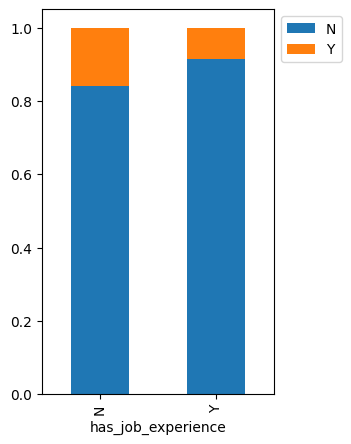

```python
#relationship between experience and training needed
stacked_barplot(df, 'has_job_experience', 'requires_job_training')
```

Of applicants that have prior job experience, ~90% do **not** need job training. It is interesting to note that of those that don't have prior experience, approx. 82% also do not require job training. This shows us that many jobs that are being applied for don't require training in general.

```
case_status            Certified  Denied    All
requires_job_training
All                        17018    8462  25480
N                          15012    7513  22525
Y                           2006     949   2955
------------------------------------------------------------------------------------------------------------------------
```

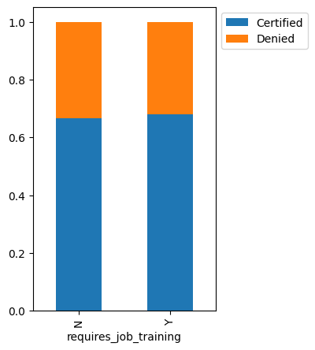

```python
#relationship between required training and visa
stacked_barplot(df, 'requires_job_training', 'case_status')
```

An applicant's need of job training does not significantly impact their visa being certified or denied.

```
full_time_position       N      Y    All
region_of_employment
All                   2707  22773  25480
South                  935   6082   7017
Northeast              804   6391   7195
West                   473   6113   6586
Midwest                450   3857   4307
Island                  45    330    375
------------------------------------------------------------------------------------------------------------------------
```

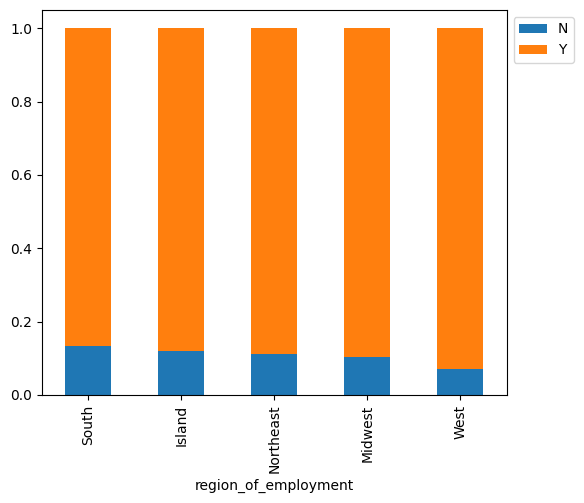

```python
#relationship between region and full time
stacked_barplot(df, 'region_of_employment', 'full_time_position')
```

Full time positions do not heavily vary amongst the region of employment

## Data Preprocessing

- ~Missing value treatment (if needed)~ Ther are no missing values in the data. We observed this in our data overview section.
- Feature engineering. We corrected negative values for the no_of_employees, we also deleted the unique id's column.
- Outlier detection and treatment
- Preparing data for modeling: We will create dummy variables from our categories.
- Any other preprocessing steps (if needed)

### Outlier Detection

- The no_of_employees column includes large values. However, we will consider these values proper, as it is not unusual for companies to employee a large amount of people (corporate businesses). The yr_of_estab column shows outliers, but we know these are years; they are considered proper values as there exist companies that have survived the test of time. The prevailing_wage section will also be considered proper values as large salaries can be found in many industries.

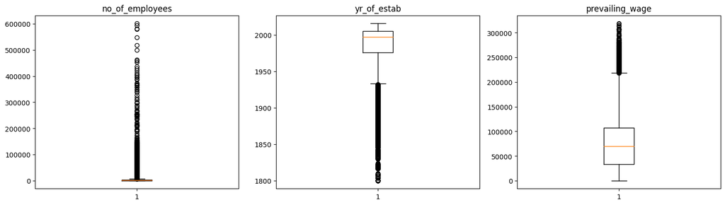

```python
# boxplot to see outliers
numeric_columns = df.select_dtypes(include=np.number).columns.tolist()


plt.figure(figsize=(15, 12))

for i, variable in enumerate(numeric_columns):
    plt.subplot(3, 3, i + 1)
    plt.boxplot(data[variable], whis=1.5)
    plt.tight_layout()
    plt.title(variable)

plt.show()
```

```python
#find largest number of employees
df.loc[df['no_of_employees']==df['no_of_employees'].max()]
```

|  | continent | education_of_employee | has_job_experience | requires_job_training | no_of_employees | yr_of_estab | region_of_employment | prevailing_wage | unit_of_wage | full_time_position | case_status |
| --- | --- | --- | --- | --- | --- | --- | --- | --- | --- | --- | --- |
| 21339 | North America | Doctorate | Y | N | 602069 | 2011 | Northeast | 25181.63 | Year | Y | Certified |

```python
#find largest value of prevailing wage
df.loc[df['prevailing_wage']==df['prevailing_wage'].max()]
```

|  | continent | education_of_employee | has_job_experience | requires_job_training | no_of_employees | yr_of_estab | region_of_employment | prevailing_wage | unit_of_wage | full_time_position | case_status |
| --- | --- | --- | --- | --- | --- | --- | --- | --- | --- | --- | --- |
| 21077 | Asia | High School | N | N | 442 | 2006 | Midwest | 319210.27 | Year | Y | Denied |

### Data Prep for Modeling

- State dependent variable / what we are predicting: We want to predict the **Certified Visas.** Thus, Certified = 1, and Denied = 0.
- Our categorical variables will be converted to dummies. Note: we will apply label encoding for the 'eduction_of_employee' column as the level of education follows a heirarchal pattern.
- We will split our data in to test/train sets following a 70:30 ratio. We will stratify our split as our data is imbalanced. We will ensure that our test/train sets follow the ratio of approx. 66% certified visas (1) and approx. 33% denied visas (0) as seen in the EDA section

```python
#state certified vs denied
df['case_status']= df['case_status'].apply(lambda x: 1 if x == 'Certified' else 0)
#check dataset
df.head(5)
```

|  | continent | education_of_employee | has_job_experience | requires_job_training | no_of_employees | yr_of_estab | region_of_employment | prevailing_wage | unit_of_wage | full_time_position | case_status |
| --- | --- | --- | --- | --- | --- | --- | --- | --- | --- | --- | --- |
| 0 | Asia | High School | N | N | 14513 | 2007 | West | 592.2029 | Hour | Y | 0 |
| 1 | Asia | Master's | Y | N | 2412 | 2002 | Northeast | 83425.6500 | Year | Y | 1 |
| 2 | Asia | Bachelor's | N | Y | 44444 | 2008 | West | 122996.8600 | Year | Y | 0 |
| 3 | Asia | Bachelor's | N | N | 98 | 1897 | West | 83434.0300 | Year | Y | 0 |
| 4 | Africa | Master's | Y | N | 1082 | 2005 | South | 149907.3900 | Year | Y | 1 |

```python
#label encoding / dummy columns
education_ranks = {"education_of_employee": {"High School":1, "Bachelor's": 2, "Master's": 3, "Doctorate": 4}}
dummy_columns = ['continent', 'has_job_experience', 'requires_job_training', 'region_of_employment', 'unit_of_wage', 'full_time_position']

#apply label encoding
df = df.replace(education_ranks)
#apply dummies
df = pd.get_dummies(df, columns=dummy_columns)

#check data
df.info()
```

```
<class 'pandas.core.frame.DataFrame'>
RangeIndex: 25480 entries, 0 to 25479
Data columns (total 26 columns):
 #   Column                          Non-Null Count  Dtype
---  ------                          --------------  -----
 0   education_of_employee           25480 non-null  category
 1   no_of_employees                 25480 non-null  int64
 2   yr_of_estab                     25480 non-null  int64
 3   prevailing_wage                 25480 non-null  float64
 4   case_status                     25480 non-null  category
 5   continent_Africa                25480 non-null  bool
 6   continent_Asia                  25480 non-null  bool
 7   continent_Europe                25480 non-null  bool
 8   continent_North America         25480 non-null  bool
 9   continent_Oceania               25480 non-null  bool
```

[output cut: 18 more lines]

```python
#fix boolean data types
df = df.astype(float)
#check again
df.info()
```

```
<class 'pandas.core.frame.DataFrame'>
RangeIndex: 25480 entries, 0 to 25479
Data columns (total 26 columns):
 #   Column                          Non-Null Count  Dtype
---  ------                          --------------  -----
 0   education_of_employee           25480 non-null  float64
 1   no_of_employees                 25480 non-null  float64
 2   yr_of_estab                     25480 non-null  float64
 3   prevailing_wage                 25480 non-null  float64
 4   case_status                     25480 non-null  float64
 5   continent_Africa                25480 non-null  float64
 6   continent_Asia                  25480 non-null  float64
 7   continent_Europe                25480 non-null  float64
 8   continent_North America         25480 non-null  float64
 9   continent_Oceania               25480 non-null  float64
```

[output cut: 18 more lines]

```python
#test and train sets
X = df.drop('case_status', axis = 1)
y= df['case_status']

#split for test and train
X_train, X_test, y_train, y_test = train_test_split(X, y, test_size=0.30, random_state=1, stratify=y)
```

```python
#check the sets
print("Shape of Training set : ", X_train.shape)
print("Shape of test set : ", X_test.shape)
print("Percentage of classes in training set:")
print(y_train.value_counts(normalize=True))
print("Percentage of classes in test set:")
print(y_test.value_counts(normalize=True))
```

```
Shape of Training set :  (17836, 25)
Shape of test set :  (7644, 25)
Percentage of classes in training set:
case_status
1.0    0.667919
0.0    0.332081
Name: proportion, dtype: float64
Percentage of classes in test set:
case_status
1.0    0.667844
0.0    0.332156
Name: proportion, dtype: float64
```

## Building bagging and boosting models

- Performance metrics commentary:
1. Model may state a visa will be certified when it is actually denied (False Pos)
2. Model may state a visa will be denied when it is actually certified (False Neg)
- We should consider both cases important to our model performance as the employement opportunity has a significant impact on people's livelihood (for both citizens and non-citizens) and the business processes within the US economy. As such, we will consider a balance between Precision and Recall Scores; the f1 Score will be our main metric of evaluation criteria so that we minimize False Positives and Negatives.

```python
#metrics
# defining a function to compute different metrics to check performance of a classification model built using sklearn
def model_performance_classification_sklearn(model, predictors, target):
    """
    Function to compute different metrics to check classification model performance

    model: classifier
    predictors: independent variables
    target: dependent variable
    """

    # predicting using the independent variables
    pred = model.predict(predictors)

    acc = accuracy_score(target, pred)  # to compute Accuracy
    recall = recall_score(target, pred)  # to compute Recall
    precision = precision_score(target, pred)  # to compute Precision
    f1 = f1_score(target, pred)  # to compute F1-score

    # creating a dataframe of metrics
    df_perf = pd.DataFrame(
        {
            "Accuracy": acc,
            "Recall": recall,
            "Precision": precision,
            "F1": f1,
        },
        index=[0],
    )

    return df_perf
```

```python
#confusion matrix visual
def confusion_matrix_sklearn(model, predictors, target):
    """
    To plot the confusion_matrix with percentages

    model: classifier
    predictors: independent variables
    target: dependent variable
    """
    y_pred = model.predict(predictors)
    cm = confusion_matrix(target, y_pred)
    labels = np.asarray(
        [
            ["{0:0.0f}".format(item) + "\n{0:.2%}".format(item / cm.flatten().sum())]
            for item in cm.flatten()
        ]
    ).reshape(2, 2)

    plt.figure(figsize=(6, 4))
    sns.heatmap(cm, annot=labels, fmt="")
    plt.ylabel("True label")
    plt.xlabel("Predicted label")
```

**Note**

1. Sample parameter grids have been provided to do necessary hyperparameter tuning. These sample grids are expected to provide a balance between model performance improvement and execution time. One can extend/reduce the parameter grid based on execution time and system configuration.
   - Please note that if the parameter grid is extended to improve the model performance further, the execution time will increase
- For Gradient Boosting:

```
param_grid = {
    "init": [AdaBoostClassifier(random_state=1),DecisionTreeClassifier(random_state=1)],
    "n_estimators": np.arange(50,110,25),
    "learning_rate": [0.01,0.1,0.05],
    "subsample":[0.7,0.9],
    "max_features":[0.5,0.7,1],
}
```

- For Adaboost:

```
param_grid = {
    "n_estimators": np.arange(50,110,25),
    "learning_rate": [0.01,0.1,0.05],
    "base_estimator": [
        DecisionTreeClassifier(max_depth=2, random_state=1),
        DecisionTreeClassifier(max_depth=3, random_state=1),
    ],
}
```

- For Bagging Classifier:

```
param_grid = {
    'max_samples': [0.8,0.9,1],
    'max_features': [0.7,0.8,0.9],
    'n_estimators' : [30,50,70],
}
```

- For Random Forest:

```
param_grid = {
    "n_estimators": [50,110,25],
    "min_samples_leaf": np.arange(1, 4),
    "max_features": [np.arange(0.3, 0.6, 0.1),'sqrt'],
    "max_samples": np.arange(0.4, 0.7, 0.1)
}
```

- For Decision Trees:

```
param_grid = {
    'max_depth': np.arange(2,6),
    'min_samples_leaf': [1, 4, 7],
    'max_leaf_nodes' : [10, 15],
    'min_impurity_decrease': [0.0001,0.001]
}
```

- For XGBoost:

```
param_grid={'n_estimators':np.arange(50,110,25),
            'scale_pos_weight':[1,2,5],
            'learning_rate':[0.01,0.1,0.05],
            'gamma':[1,3],
            'subsample':[0.7,0.9]
}
```

## Bagging Processes:

- Decision Tree Process includes creating a Decision Tree with default parameters and then tuning the Decision Tree with hyperparameters provided in the project notebook.
- Bagging Classifier Process includes creating a Bagging Classifier with default parameters and then tuning the Model with hyperparameters provided in the project notebook.
- Random Forest Process includes creating a Random Forest with default parameters and then tuning the Random Forest with hyperparameters provided in the project notebook.

### Decision Tree Process

```python
#vanilla decision tree
dtree = DecisionTreeClassifier(criterion='gini',class_weight='balanced',random_state=1)
```

```python
dtree.fit(X_train, y_train)
```

```
DecisionTreeClassifier(class_weight='balanced', random_state=1)
```

```python
#check performance of Dtree train
dtree_train_perf = model_performance_classification_sklearn(dtree, X_train, y_train)
dtree_train_perf
```

|  | Accuracy | Recall | Precision | F1 |
| --- | --- | --- | --- | --- |
| 0 | 1.0 | 1.0 | 1.0 | 1.0 |

```python
#check performance of Dtree test
dtree_test_perf = model_performance_classification_sklearn(dtree, X_test, y_test)
dtree_test_perf
```

|  | Accuracy | Recall | Precision | F1 |
| --- | --- | --- | --- | --- |
| 0 | 0.652276 | 0.74809 | 0.735696 | 0.741841 |

We see that our initial decision tree heavily overfits the data. We will improve the model using hyperparameter tuning.

```python
# Tuning the decision tree
dtree_estimator = DecisionTreeClassifier(class_weight='balanced',random_state=1)

# Grid of parameters to choose from
param_grid = {
    'max_depth': np.arange(2,6),
    'min_samples_leaf': [1, 4, 7],
    'max_leaf_nodes' : [10, 15],
    'min_impurity_decrease': [0.0001,0.001]
}
# Type of scoring used to compare parameter combinations
scorer = metrics.make_scorer(metrics.f1_score)

# Run the grid search
grid_obj = GridSearchCV(dtree_estimator, param_grid, scoring=scorer)
grid_obj = grid_obj.fit(X_train, y_train)

# Set the clf to the best combination of parameters
dtree_estimator = grid_obj.best_estimator_

# Fit the best algorithm to the data.
dtree_estimator.fit(X_train, y_train)
```

```
DecisionTreeClassifier(class_weight='balanced', max_depth=4, max_leaf_nodes=15,
                       min_impurity_decrease=0.001, random_state=1)
```

```python
#check performance of hyperparam dtree train
dtree_estimator_train_perf = model_performance_classification_sklearn(dtree_estimator, X_train, y_train)
dtree_estimator_train_perf
```

|  | Accuracy | Recall | Precision | F1 |
| --- | --- | --- | --- | --- |
| 0 | 0.716641 | 0.779569 | 0.792744 | 0.786101 |

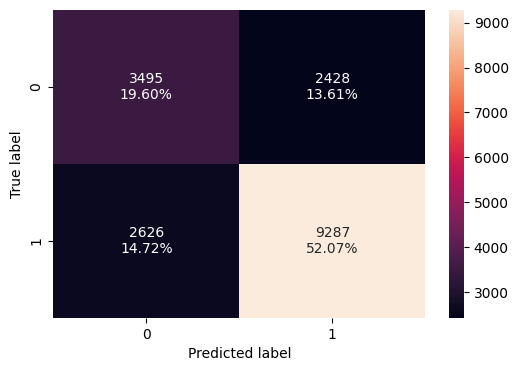

```python
#check confusion matrix train
confusion_matrix_sklearn(dtree_estimator, X_train, y_train)
```

```python
#check performance of hyperparam dtree test
dtree_estimator_test_perf = model_performance_classification_sklearn(dtree_estimator, X_test, y_test)
dtree_estimator_test_perf
```

|  | Accuracy | Recall | Precision | F1 |
| --- | --- | --- | --- | --- |
| 0 | 0.715594 | 0.78237 | 0.789796 | 0.786066 |

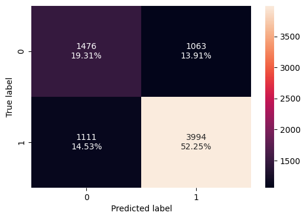

```python
#check confusion matrix test
confusion_matrix_sklearn(dtree_estimator, X_test, y_test)
```

Comments to compare Default Decision Tree to Tuned Decision Tree: The Default Decision Tree suffers from overfitting and does not work well on unseen data. The Tuned Decision Tree shows an improvement; the performance metrics for Accurcacy, Recall, Precision, and F1 are comparable between train and test sets. The F1_Score is 0.786 (test), which is better than the Default Tree.

### Bagging Classifier Process

```python
#vanilla bagging
bagging = BaggingClassifier(random_state=1)
bagging.fit(X_train,y_train)
```

```
BaggingClassifier(random_state=1)
```

```python
#check performance of Bagging train
bagging_train_perf = model_performance_classification_sklearn(bagging, X_train, y_train)
bagging_train_perf
```

|  | Accuracy | Recall | Precision | F1 |
| --- | --- | --- | --- | --- |
| 0 | 0.983012 | 0.983463 | 0.991034 | 0.987234 |

```python
#check performance of Bagging test
bagging_test_perf = model_performance_classification_sklearn(bagging, X_test, y_test)
bagging_test_perf
```

|  | Accuracy | Recall | Precision | F1 |
| --- | --- | --- | --- | --- |
| 0 | 0.697017 | 0.774731 | 0.77231 | 0.773518 |

The data suffers from overfitting. The F1 Score on the test data is lower than our Tuned Decision Tree performance. We will try to improve the Bagging Classifier by working with Hyperparameters.

```python
#tuning bagging
bagging_estimator_tuned = BaggingClassifier(random_state=1)

# Grid of parameters to choose from
param_grid = {
    'max_samples': [0.8,0.9,1],
    'max_features': [0.7,0.8,0.9],
    'n_estimators' : [30,50,70],
}

# Type of scoring used to compare parameter combinations
scorer = metrics.make_scorer(metrics.f1_score)

# Run the grid search
grid_obj = GridSearchCV(bagging_estimator_tuned, param_grid=param_grid, scoring=scorer, cv=5)
grid_obj = grid_obj.fit(X_train, y_train)

# Set the clf to the best combination of parameters
bagging_estimator_tuned = grid_obj.best_estimator_

# Fit the best algorithm to the data.
bagging_estimator_tuned.fit(X_train, y_train)
```

```
BaggingClassifier(max_features=0.7, max_samples=0.8, n_estimators=70,
                  random_state=1)
```

```python
#check performance of tuned Bagging train
bagging_tuned_train_perf = model_performance_classification_sklearn(bagging_estimator_tuned, X_train, y_train)
bagging_tuned_train_perf
```

|  | Accuracy | Recall | Precision | F1 |
| --- | --- | --- | --- | --- |
| 0 | 0.997365 | 0.999832 | 0.996236 | 0.998031 |

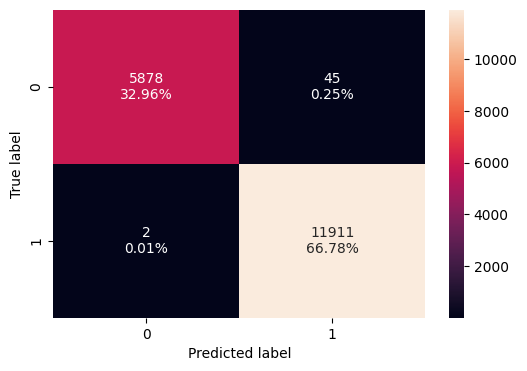

```python
#check confusion matrix tuned bagging train
confusion_matrix_sklearn(bagging_estimator_tuned, X_train, y_train)
```

```python
#check performance of tuned Bagging test
bagging_tuned_test_perf = model_performance_classification_sklearn(bagging_estimator_tuned, X_test, y_test)
bagging_tuned_test_perf
```

|  | Accuracy | Recall | Precision | F1 |
| --- | --- | --- | --- | --- |
| 0 | 0.724882 | 0.865426 | 0.757285 | 0.807752 |

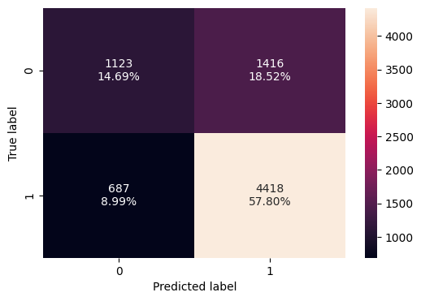

```python
#check confusion matrix tuned bagging test
confusion_matrix_sklearn(bagging_estimator_tuned, X_test, y_test)
```

Comments to compare Default Bagging to Tuned Bagging: Both the Default and Tuned Bagging Models suffer from overfitting the data. We see this because both models' performance metrics score in the 90-percentile on train sets, then have a large disparity when run on the test sets. Although the F1_Score of the Tuned Bagging Classifier is better than the Tuned Decision Tree (.807), the difference between the F1_score of the train and test sets is greater than 10%. The model foes not perform well on unseen data.

### Random Forest Process

```python
#vanilla RF
rf = RandomForestClassifier(class_weight = 'balanced', random_state=1)
rf.fit(X_train,y_train)
```

```
RandomForestClassifier(class_weight='balanced', random_state=1)
```

```python
#check RF performance train
rf_train_perf = model_performance_classification_sklearn(rf, X_train, y_train)
rf_train_perf
```

|  | Accuracy | Recall | Precision | F1 |
| --- | --- | --- | --- | --- |
| 0 | 1.0 | 1.0 | 1.0 | 1.0 |

```python
#check RF performance test
rf_test_perf = model_performance_classification_sklearn(rf, X_test, y_test)
rf_test_perf
```

|  | Accuracy | Recall | Precision | F1 |
| --- | --- | --- | --- | --- |
| 0 | 0.723051 | 0.845054 | 0.764894 | 0.802978 |

The Random Forest displays a problem with overfitting with 100% metrics on the train data and significant decreases on the test data. We will tuned the Random Forest Model to see if we can make improvements.

```python
# tuning Random Forest
rf_estimator = RandomForestClassifier(class_weight='balanced', random_state=1, oob_score=True, bootstrap=True)

# Grid of parameters to choose from
param_grid = {
    "n_estimators": [50,110,25],
    "min_samples_leaf": np.arange(1, 4),
    "max_features": [np.arange(0.3, 0.6, 0.1),'sqrt'],
    "max_samples": np.arange(0.4, 0.7, 0.1)
}

# Type of scoring used to compare parameter combinations
scorer = metrics.make_scorer(metrics.f1_score)

# Run the grid search
grid_obj = GridSearchCV(rf_estimator, param_grid, scoring=scorer,cv=5, n_jobs=-1)
grid_obj = grid_obj.fit(X_train, y_train)

# Set the clf to the best combination of parameters
rf_estimator = grid_obj.best_estimator_

# Fit the best algorithm to the data.
rf_estimator.fit(X_train, y_train)
```

```
RandomForestClassifier(class_weight='balanced', max_samples=0.4,
                       n_estimators=110, oob_score=True, random_state=1)
```

```python
#check tuned RF performance train
rf_estimator_train_perf = model_performance_classification_sklearn(rf_estimator, X_train, y_train)
rf_estimator_train_perf
```

|  | Accuracy | Recall | Precision | F1 |
| --- | --- | --- | --- | --- |
| 0 | 0.919152 | 0.975657 | 0.909824 | 0.941591 |

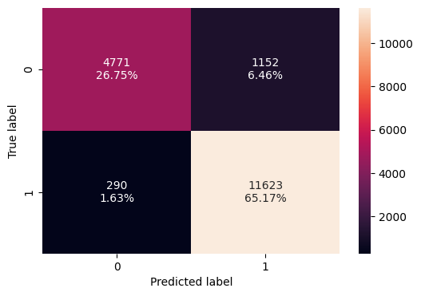

```python
#check confusion matrix tuned RF train
confusion_matrix_sklearn(rf_estimator, X_train, y_train)
```

```python
#check tuned RF performance test
rf_estimator_test_perf = model_performance_classification_sklearn(rf_estimator, X_test, y_test)
rf_estimator_test_perf
```

|  | Accuracy | Recall | Precision | F1 |
| --- | --- | --- | --- | --- |
| 0 | 0.731947 | 0.863859 | 0.765094 | 0.811482 |

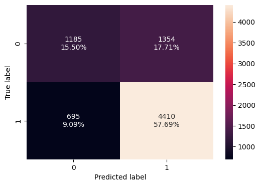

```python
#check confusion matrix tuned RF test
confusion_matrix_sklearn(rf_estimator, X_test, y_test)
```

Comments to compare Default Random Forest to Tuned Random Forest: The Default Random Forest has an issue with oversitting as the Train Performance scores 100% on all metrics then drops by more than 15% on the Test set. The Default Random Forest does not perform well on unseen data. The Tuned Random Forest improves on the over-fitting issue, as the performance on the Train set is no longer 100%. The F1_Score on the Test set for the Tuned Random Forest is the highest we have seen at 0.811. We would like to see more comparable scores between the Train and Test sets, but we see improvements with this model.